# Hierarchical Models

Jake Barrett

9/23/2021

$~$

## Example 1: Mixed-Effects Model (Repeated Measures)

$~$

Concerned with the potential ramifications of the “browning” of high mountain lakes due to climate change, Symons et al. 2019 used otolith-derived growth data to examine the relationship between fish growth and environmental factors, such as total dissolved carbon and isotopic signatures.

I sub-sampled this dataset for 28 individuals (based on convenience) in order to examine whether growth rates differed by species (Brook or Rainbow Trout) and were affected by lake elevation.

$~$

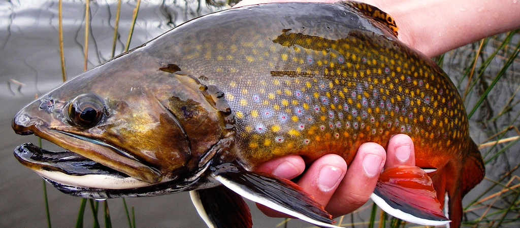

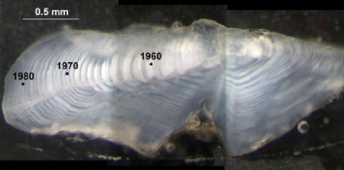

$~$

1.1 Data visualization and summary

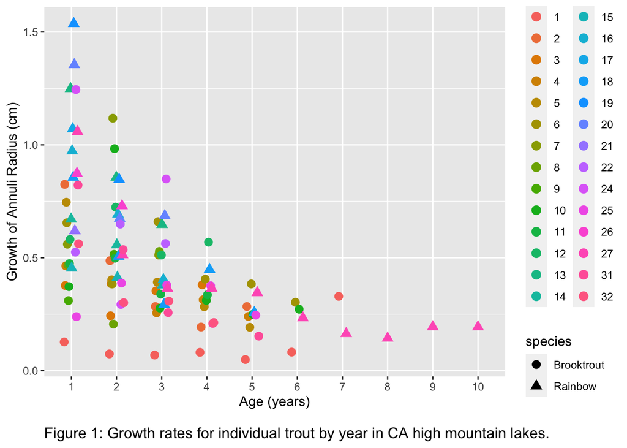

```r
fish <- read.csv("data/HMLgrowth.csv")

fish$individual <- as.factor(fish$individual)
fish$age <-as.factor(fish$age)

ggplot(fish, aes(age, growth.rate, colour=individual, shape=species)) +
  geom_point(size=3, position = position_dodge2(width=.33, preserve = "total")) +
  xlab ("Age (years)") +
  ylab ("Growth of Annuli Radius (cm)") +
  labs(caption="Figure 1: Growth rates for individual trout by year in CA high mountain lakes.") +
  theme(plot.caption=element_text(size=12, hjust=0, margin=margin(15,0,0,0)))
```

$~$

**Just to take a look at some life history information for all of the fish in this dataset:**

```r
fish_means <- fish %>%
  group_by(age) %>%
  summarise(mean_growth=mean(growth.rate),
            se_growth=sd(growth.rate)/sqrt(n()))
fish_means
```

```
## # A tibble: 10 x 3
##    age   mean_growth se_growth
##    <fct>       <dbl>     <dbl>
##  1 1           0.717    0.0667
##  2 2           0.538    0.0480
##  3 3           0.423    0.0382
##  4 4           0.320    0.0326
##  5 5           0.240    0.0299
##  6 6           0.223    0.0490
##  7 7           0.246    0.0825
##  8 8           0.144   NA
##  9 9           0.194   NA
## 10 10          0.194   NA
```

$~$

**Raw means by species:**

```r
fish_means_sp <- fish %>%
  group_by(species) %>%
  summarise(mean_growth=mean(growth.rate),
            se_growth=sd(growth.rate)/sqrt(n()))
fish_means_sp
```

```
## # A tibble: 2 x 3
##   species    mean_growth se_growth
##   <fct>            <dbl>     <dbl>
## 1 Brooktrout       0.413    0.0272
## 2 Rainbow          0.618    0.0593
```

$~$

1.2 Model formation

Because I was interested in whether growth rates are different between species and are influenced by the elevation of high mountain lakes, I included these as fixed effects in my model. I also included random effects in order to account for natural variation at the individual and species levels.

```r
mixed_HML <- lmer(growth.rate~(species*elevation)+(1|species/individual), data=fish)
anova(mixed_HML)
```

```
## Type III Analysis of Variance Table with Satterthwaite's method
##                     Sum Sq  Mean Sq NumDF  DenDF F value Pr(>F)
## species           0.053231 0.053231     1 27.040  1.0585 0.3127
## elevation         0.006195 0.006195     1 25.205  0.1232 0.7285
## species:elevation 0.088257 0.088257     1 25.205  1.7551 0.1971
```

```r
summary(mixed_HML)
```

```
## Linear mixed model fit by REML. t-tests use Satterthwaite's method [
## lmerModLmerTest]
## Formula: growth.rate ~ (species * elevation) + (1 | species/individual)
##    Data: fish
##
## REML criterion at convergence: 47.5
##
## Scaled residuals:
##     Min      1Q  Median      3Q     Max
## -1.6093 -0.5667 -0.2129  0.3386  2.9153
##
## Random effects:
##  Groups             Name        Variance Std.Dev.
##  individual:species (Intercept) 0.02765  0.1663
##  species            (Intercept) 0.02066  0.1437
##  Residual                       0.05029  0.2242
## Number of obs: 109, groups:  individual:species, 28; species, 2
##
## Fixed effects:
##                            Estimate Std. Error         df t value Pr(>|t|)
## (Intercept)               0.9288479  0.7692939 23.6899381   1.207    0.239
## speciesRainbow           -1.0613908  1.0316274 27.0398908  -1.029    0.313
## elevation                -0.0001646  0.0002496 21.9513102  -0.659    0.517
## speciesRainbow:elevation  0.0004478  0.0003380 25.2051232   1.325    0.197
##
## Correlation of Fixed Effects:
##             (Intr) spcsRn elevtn
## speciesRnbw -0.746
## elevation   -0.980  0.731
## spcsRnbw:lv  0.724 -0.977 -0.738
## fit warnings:
## Some predictor variables are on very different scales: consider rescaling
## optimizer (nloptwrap) convergence code: 0 (OK)
## unable to evaluate scaled gradient
## Model failed to converge: degenerate  Hessian with 1 negative eigenvalues
```

$~$

1.3 Check model

```r
#performance::check_model(mixed_HML) #Error: argument 1 is not a vector? IDK
```

$~$

1.4 Calculating marginal means

Because individuals were different ages when caught and sampled, they would have contributed differently to the mean growth rates for each species (older fish would have contributed more data).

```r
mixed_HML_emm_sp <- emmeans(mixed_HML, "species")
```

```
## NOTE: Results may be misleading due to involvement in interactions
```

```r
mixed_HML_emm_sp
```

```
##  species    emmean    SE   df lower.CL upper.CL
##  Brooktrout  0.436 0.152 1971    0.139    0.734
##  Rainbow     0.715 0.159  882    0.403    1.027
##
## Degrees-of-freedom method: kenward-roger
## Confidence level used: 0.95
```

$~$

**Let’s compare the raw and adjusted means:**

```r
data_emm_sp <- as.data.frame(mixed_HML_emm_sp)
data_emm_sp
```

```
##      species    emmean        SE        df  lower.CL  upper.CL
## 1 Brooktrout 0.4363958 0.1518797 1971.3871 0.1385342 0.7342574
## 2    Rainbow 0.7148978 0.1588255  882.1958 0.4031779 1.0266177
```

```r
fish_means_sp
```

```
## # A tibble: 2 x 3
##   species    mean_growth se_growth
##   <fct>            <dbl>     <dbl>
## 1 Brooktrout       0.413    0.0272
## 2 Rainbow          0.618    0.0593
```

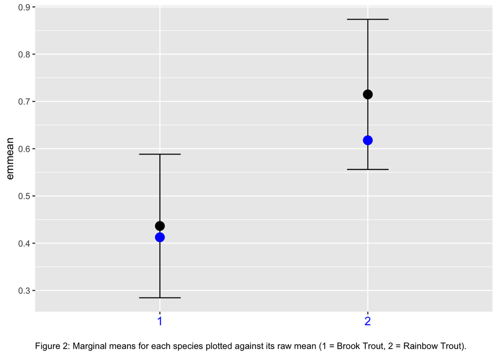

```r
ggplot(data_emm_sp, aes(x=species, y=emmean)) +
  geom_point(size=4) +
  geom_errorbar(aes(ymin=emmean-SE, ymax=emmean+SE), width=.2) +
  labs(caption="Figure 2: Marginal means for each species plotted against its raw mean (1 = Brook Trout, 2 = Rainbow Trout).") +
  geom_point(data=fish_means_sp, size=4, x=fish_means_sp$species, y=fish_means_sp$mean_growth,   color="blue") +
  theme(axis.text.x = ggtext::element_markdown(color = "blue", size = 12)) +
  scale_x_discrete(name = NULL, labels = labels) +
  theme(plot.caption=element_text(size=9, hjust=0, margin=margin(15,0,0,0)))
```

$~$

**No meaningful difference between the raw and model-adjusted means** - given that we didn’t uncover any significant effects, this makes sense!

$~$

## Example 2: Mixed-Effects Model (Nested Measures)

$~$

Yamada and Masayo (2016) examined changes in song characteristics of Bengalese Finches that were exposed to either a normal or high nutrition diet.

Here, I was interested in examining the ability of the experimental treatment to explain differences in observed song duration.

$~$

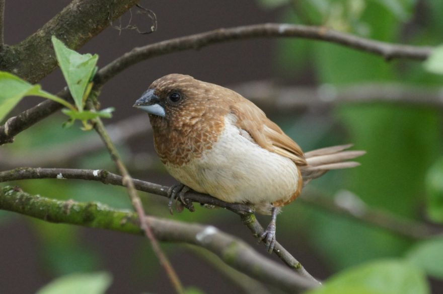

$~$

2.1 Data visualization

```r
bird <- read.csv("data/nutrition_birdsong_after.csv") #19 individuals

names(bird)
```

```
## [1] "Bird.ID"
## [2] "Song.duration..sec."
## [3] "Total.no..notes..song"
## [4] "Tempo"
## [5] "Before.After.experiment"
## [6] "Experimental.group..Control.High.nutrition."
```

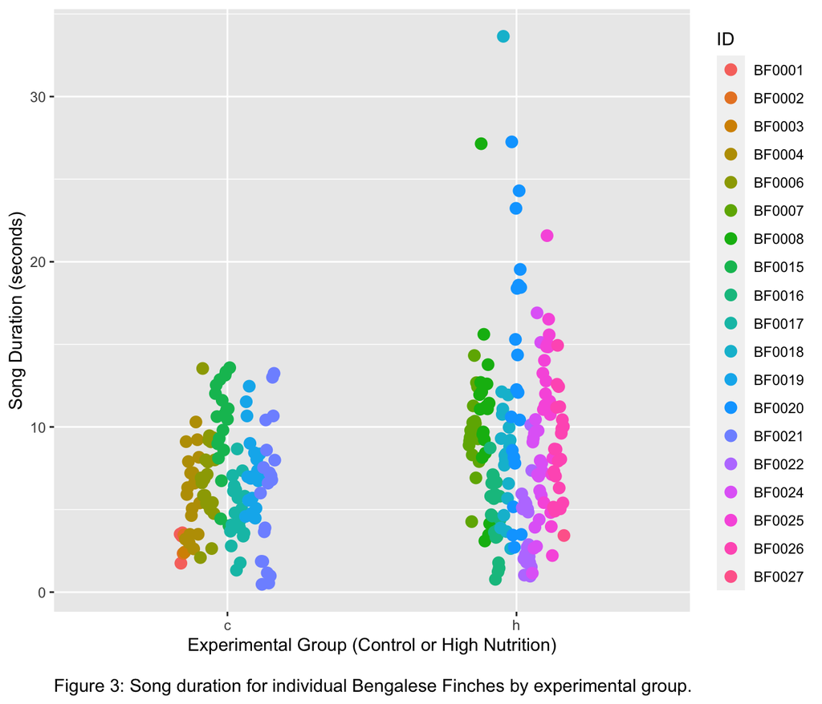

```r
colnames(bird) <- c("ID", "song.duration", "total.notes", "tempo", "before.after", "diet")

ggplot(bird, aes(diet, song.duration, colour = ID)) +
  geom_point(size=3, position = position_dodge2(width=.33, preserve = "total"))+
  xlab ("Experimental Group (Control or High Nutrition)") +
  ylab ("Song Duration (seconds)") +
  labs(caption="Figure 3: Song duration for individual Bengalese Finches by experimental group.") +
  theme(plot.caption=element_text(size=11, hjust=0, margin=margin(15,0,0,0)))
```

$~$

2.2 Model formation and evaluation

Because I was interested in the effect of diet (high nutrition or normal-control) on the song duration of the finches, I included diet as my only fixed effect and a random effect accounting for the natural variation between individuals, as well as the fact that individuals were only found in one of the treatment groups.

```r
bird.1 <- lmer(song.duration ~ diet + (1|diet/ID), data = bird)
bird.1
```

```
## Linear mixed model fit by REML ['lmerModLmerTest']
## Formula: song.duration ~ diet + (1 | diet/ID)
##    Data: bird
## REML criterion at convergence: 1734.933
## Random effects:
##  Groups   Name        Std.Dev.
##  ID:diet  (Intercept) 2.5169
##  diet     (Intercept) 0.7813
##  Residual             3.8475
## Number of obs: 308, groups:  ID:diet, 19; diet, 2
## Fixed Effects:
## (Intercept)        dieth
##       6.055        2.575
## optimizer (nloptwrap) convergence code: 0 (OK) ; 0 optimizer warnings; 2 lme4 warnings
```

```r
anova(bird.1)
```

```
## Type III Analysis of Variance Table with Satterthwaite's method
##      Sum Sq Mean Sq NumDF  DenDF F value Pr(>F)
## diet 33.661  33.661     1 45.959  2.2739 0.1384
```

```r
summary(bird.1)
```

```
## Linear mixed model fit by REML. t-tests use Satterthwaite's method [
## lmerModLmerTest]
## Formula: song.duration ~ diet + (1 | diet/ID)
##    Data: bird
##
## REML criterion at convergence: 1734.9
##
## Scaled residuals:
##     Min      1Q  Median      3Q     Max
## -2.6029 -0.5528 -0.0207  0.4224  6.3628
##
## Random effects:
##  Groups   Name        Variance Std.Dev.
##  ID:diet  (Intercept)  6.3349  2.5169
##  diet     (Intercept)  0.6104  0.7813
##  Residual             14.8031  3.8475
## Number of obs: 308, groups:  ID:diet, 19; diet, 2
##
## Fixed effects:
##             Estimate Std. Error     df t value Pr(>|t|)
## (Intercept)    6.055      1.244 45.217   4.869 1.41e-05 ***
## dieth          2.575      1.707 45.959   1.508    0.138
## ---
## Signif. codes:  0 '***' 0.001 '**' 0.01 '*' 0.05 '.' 0.1 ' ' 1
##
## Correlation of Fixed Effects:
##       (Intr)
## dieth -0.728
## optimizer (nloptwrap) convergence code: 0 (OK)
## unable to evaluate scaled gradient
## Model failed to converge: degenerate  Hessian with 1 negative eigenvalues
```

$~$

**Non-significant effect of diet on song duration (ANOVA), but a significant effect from the control diet in the summary table…. Not sure how to interpret this?**

$~$